# R Package Versioning

## Motivation

- We want to provide stable, discrete versions of packages from which users can install to ensure stability and reproducibility

## Semantic Versioning

- Also known as SemVer, [Semantic Versioning](https://semver.org/) is a universal approach to versioning software development projects (e.g. R packages) that allows for accurate tracking of development
- Broken into three numbers, semantic versioning follows the format of  
  *major version*.*minor version*.*patch*

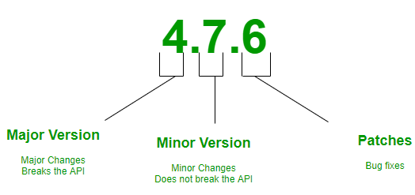

Source: https://www.geeksforgeeks.org/introduction-semantic-versioning/

- The first number indicates a major version number. This version includes major changes to the package that are likely to break code from previous versions
- The second number indicates a minor version, which will be compatible with previous minor versions.
  - An R package example could be adding an additional function without altering how previously released functions operate
- Lastly, the third number indicates the patch version. These are usually bug fixes and should always be compatible across the patch numbers
- Generally, a first release will be 0.1.0 and the first major release comes at 1.0.0 once rapid development has paused and a stable product is ready
- There’s no hard upper limit to each number, but if your minor versions begin to get very high, you may need to be mindful of compatibility within the major version you are still developing under (i.e. 1.17.0 is still compatible with 1.1.0)

## Best Practices

### GitHub

- Utilize [GitHub releases](https://docs.github.com/en/repositories/releasing-projects-on-github/managing-releases-in-a-repository) to denote versions
  - Pair with pull requests to make more coherent, traceable releases
- For minor and major releases, create branches titled the number of the release
  - For example, when getting ready for 1.0.0 release, create a branch called “1.0.0” and merge development branches into 1.0.0 until ready for release. Then merge 1.0.0 into main and create a GitHub release for 1.0.0
- In the release notes, explain the major changes and anything that may change or break
- A major release should be joined by a detailed readme or documentation release

### Function Deprecation

- The package [{lifecycle}](https://lifecycle.r-lib.org/articles/communicate.html) can be useful to express the status of a given function
  - You can indicate three levels of [deprecation](https://lifecycle.r-lib.org/reference/deprecate_soft.html) for a function and direct users to an alternative
  - {lifecycle} can be initiated in a package with `usethis::use_lifecycle()`

## Other Resources

[versioning guidelines](https://combine-australia.github.io/r-pkg-dev/versioning.html)

[blog post from R legend (and knitr creator) Yihui Xie](https://yihui.org/en/2013/06/r-package-versioning/)